# UMI-Anchored Effective Scaling With GSE164378

This tutorial fits the five-parameter effective model to RNA–ADT mutual information measured across UMI depths. One additional parameter, $B_0$, then calibrates the cell-number response around the known reference point.

## Empirical UMI calibration

At every UMI depth, empirical MI is calculated with all 4,000 cells and fixed rank-12 RNA and ADT subspaces. The effective aspect ratio uses the 2,000-feature RNA input dimension, $d=2000$, rather than the retained MI rank.

```r
umi_observed <- scscale_empirical_inu_grid(
  X,
  Y,
  n_grid = n_reference,
  sampling_rates = rates,
  r = mi_rank,
  n_replicates = 3,
  n_workers = n_workers,
  seed = 164378
)
```

## Fit the effective model

The five fitted parameters are
$$(I_\infty,C,\theta_Y,a,b).$$
The nonlinear optimizer varies only $(\theta_Y,a,b)$. For each optimizer evaluation, $(I_\infty,C)$ are solved by constrained weighted least squares. The effective signal remains linear, $q(U)=a+bU$. Only its recoverability at the BBP boundary is smoothed:
$$\theta_X(n,U)=\frac{q(U)}{q(U)+1}G\!\left(q(U);d/n\right),$$
$$G(q;c)=
\begin{cases}
0, & q^2\le c,\\
\exp\{-c/(q^2-c)\}, & q^2>c.
\end{cases}$$
This gate turns on smoothly at $q=\sqrt{d/n}$, approaches the original strong-signal law, and introduces no new parameter.

```r
fit <- scscale_effective_fit(
  umi_observed,
  d = effective_dimension,
  n_reference = n_reference,
  U_reference = U_reference,
  weighting = "inverse_variance",
  n_starts = 10,
  seed = 164378
)

data.frame(
  parameter = names(fit$coefficients),
  estimate = unname(fit$coefficients),
  row.names = NULL
)
```

```
##    parameter     estimate
## 1 I_infinity 6.041975e+00
## 2          C 2.054182e+00
## 3    theta_Y 6.031052e-01
## 4          a 6.979056e-05
## 5          b 1.441956e-03
```

## Calibrate cell-number scaling

```r
cell_observed <- scscale_empirical_inu_grid(
  X,
  Y,
  n_grid = cell_grid,
  sampling_rates = 1,
  r = mi_rank,
  n_replicates = 3,
  n_workers = n_workers,
  seed = 264378
)
fit_gamma <- scscale_effective_cell_calibrate(
  fit,
  cell_observed,
  weighting = "equal"
)
fit <- scscale_effective_cell_calibrate_B(
  fit,
  cell_observed,
  weighting = "equal"
)

summarize_mi <- function(data, x) {
  split_data <- split(data$I_empirical, data[[x]])
  data.frame(
    x = as.numeric(names(split_data)),
    I_mean = vapply(split_data, mean, numeric(1)),
    I_sd = vapply(split_data, sd, numeric(1))
  )
}

umi_points <- summarize_mi(umi_observed, "U")
cell_points <- summarize_mi(cell_observed, "n")

umi_curve <- predict(
  fit,
  n = n_reference,
  U = seq(min(umi_points$x), U_reference, length.out = 300),
  type = "all"
)
cell_curve <- predict(
  fit,
  n = seq(min(cell_grid), max(cell_grid), length.out = 300),
  U = U_reference,
  type = "all"
)
```

The reference count $n_0=4000$ is fixed by the UMI experiment, not fitted. The cell-number data estimate one direct scale, $B_0$, at the reference UMI depth $U_0$. The original theoretical scale is
$$A_n(U)=
\frac{\theta_Yd}
{q(U)\{q(U)+1\}\{1-\theta_Yq(U)/(q(U)+1)\}},$$
and its relative UMI dependence transfers the fitted scale:
$$B(U)=B_0\frac{A_n(U)}{A_n(U_0)}.$$
Let $I_0(U)$ be the UMI-fit prediction at $n_0$, translated by the single empirical anchor at $(n_0,U_0)$. The cell-number prediction is
$$I_B(n,U)=I_0(U)+C
\log\left\{
\frac{1+B(U)/n_0}{1+B(U)/n}
\right\}.$$
All five UMI-fit parameters remain fixed. Only $B_0$ is estimated from cell-number observations. Because only the ratio $A_n(U)/A_n(U_0)$ is used, the arbitrary absolute scale of $q(U)$ does not enter the cell calibration. No BBP indicator or additional gate is applied to this correction.

```r
data.frame(
  parameter = "B_reference",
  estimate = unname(fit$coefficients[["B_reference"]]),
  anchor_n0 = fit$n_reference,
  anchor_I0 = fit$cell_anchor$I_empirical,
  theoretical_anchor = fit$cell_anchor$I_model,
  anchor_offset = fit$cell_anchor$offset,
  row.names = NULL
)
```

```
##     parameter estimate anchor_n0 anchor_I0 theoretical_anchor anchor_offset
## 1 B_reference 70.61112      4000   5.71147           5.710512  0.0009582194
```

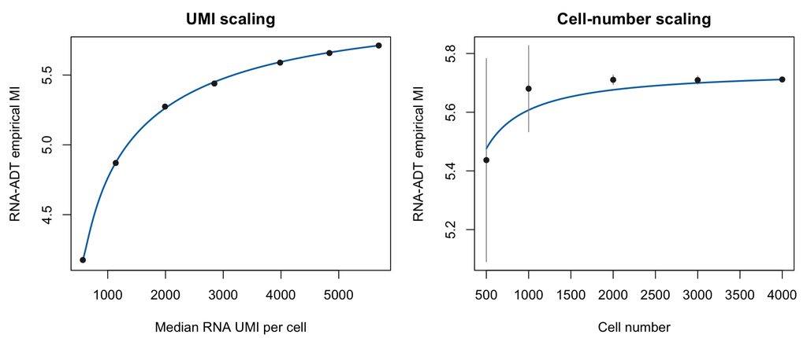

Solid lines are effective-model fits. Points and error bars are empirical MI means and standard deviations.

```r
data.frame(
  cell_model = c("Previous gamma calibration", "Direct B0 calibration"),
  parameter = c("gamma", "B_reference"),
  estimate = c(
    unname(fit_gamma$coefficients[["gamma"]]),
    unname(fit$coefficients[["B_reference"]])
  ),
  UMI_fit_RMSE = fit$metrics$rmse,
  cell_fit_RMSE = c(fit_gamma$cell_metrics$rmse, fit$cell_metrics$rmse)
)
```

```
##                   cell_model   parameter  estimate UMI_fit_RMSE cell_fit_RMSE
## 1 Previous gamma calibration       gamma  2.045989  0.006497403     0.0402925
## 2      Direct B0 calibration B_reference 70.611122  0.006497403     0.0402925
```

## Joint cell-number and UMI scaling

The fitted model directly defines $I(n,U)$. The curves below vary cell number at five observed UMI depths; no additional parameters are fitted.

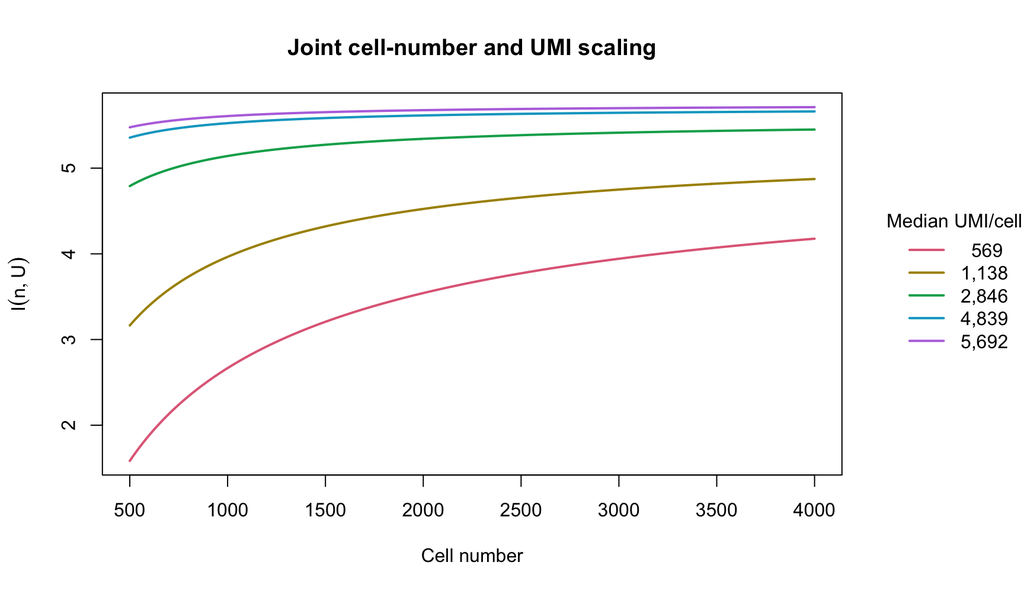

Predicted cell-number scaling at five observed median RNA UMI depths.